# Credit Risk Modelling – Probability of Default

The goal of this project is to build a model that estimates the probability of default for unsecured personal loans.

The analysis follows a structured pipeline including exploratory data analysis, feature engineering, model training and evaluation.

The final model will generate probability of default predictions for observations in the test dataset.

```python
import pandas as pd
import numpy as np


import matplotlib.pyplot as plt
import seaborn as sns


from sklearn.model_selection import train_test_split
from sklearn.preprocessing import StandardScaler
from sklearn.metrics import roc_auc_score, roc_curve
from sklearn.linear_model import LogisticRegression


pd.set_option('display.max_columns', 300)
```

load data

```python
#https://drive.google.com/file/d/12_6OjeIS8qBdyNR2JuMn1mKEIXU3CfL8/view?usp=sharing
file_id = '12_6OjeIS8qBdyNR2JuMn1mKEIXU3CfL8'
download_url = f'https://drive.google.com/uc?export=download&id={file_id}'

# Trying with semicolon as a delimiter and skipping bad lines
train = pd.read_csv(download_url, encoding='iso-8859-1', sep=';', on_bad_lines='skip')
train
```

|  | application_id | loan_date_created | activeloan_coalt | applicationamount | applicationprice | avgbetweenapplications | avgbetweenapprovedapplications | avgextensions | avgloanterm | countapplicationsafterlastloanclose | countrejectedapplications | countrejectedapplicationsafterlastloanclose | customerincomecurrent | customerincomeprevious | employmentstatus | income_charge | onavgdpd | ondpd_coalt | ondpd_ext_coalt | onlastloandpd_ext_coalt | onmaxdpd_coalt | onmaxdpd_ext_coalt | onsex | diff_customerincome | chap_countapplication | chap_countrejectedapplications | max_ondpd | max_ondpd_ext | max_onlastloandpd_ext | … |
| --- | --- | --- | --- | --- | --- | --- | --- | --- | --- | --- | --- | --- | --- | --- | --- | --- | --- | --- | --- | --- | --- | --- | --- | --- | --- | --- | --- | --- | --- | --- |
| 0 | 4275 | 29.11.2020 | 0 | 2500 | 402,11 | 0 | 0 | 0 | 0 | 1 | 0 | 0 | 4000 | 0 | 1 | 0,1 | 0 | 0 | 0 | 0 | 0 | 0 | 1 | -4000 | 1 | NaN | 0 | 0 | 0 | … |
| 1 | 9635 | 17.02.2021 | 0 | 600 | 0 | 0 | 0 | 0 | 30 | 1 | 0 | 0 | 3000 | 0 | 1 | 0 | 0 | 0 | 0 | 0 | 0 | 0 | 1 | -3000 | 1 | NaN | 0 | 0 | 0 | … |
| 2 | 5383 | 14.12.2020 | 0 | 500 | 0 | 0 | 0 | 0 | 0 | 1 | 0 | 0 | 2950 | 0 | 7 | 0 | 0 | 0 | 0 | 0 | 0 | 0 | 1 | -2950 | 1 | NaN | 0 | 0 | 0 | … |
| 3 | 442 | 05.10.2020 | 0 | 500 | 0 | 0,01 | 0 | 0 | 0 | 2 | 0 | 0 | 1920 | 0 | 1 | 0 | 0 | 0 | 0 | 0 | 0 | 0 | 2 | -1920 | 2 | NaN | 0 | 0 | 0 | … |
| 4 | 5070 | 10.12.2020 | 0 | 300 | 0 | 0 | 0 | 0 | 0 | 1 | 0 | 0 | 2500 | 0 | 1 | 0 | 0 | 0 | 0 | 0 | 0 | 0 | 1 | -2500 | 1 | NaN | 0 | 0 | 0 | … |
| ... | ... | ... | ... | ... | ... | ... | ... | ... | ... | ... | ... | ... | ... | ... | ... | ... | ... | ... | ... | ... | ... | ... | ... | ... | ... | ... | ... | ... | ... | … |
| 9995 | 4831 | 07.12.2020 | 0 | 1500 | 120,63 | 0 | 0 | 0 | 0 | 1 | 0 | 0 | 5000 | 0 | 10 | 0,02 | 0 | 0 | 0 | 0 | 0 | 0 | 2 | -5000 | 1 | NaN | 0 | 0 | 0 | … |
| 9996 | 4013 | 25.11.2020 | 0 | 1000 | 80,42 | 0 | 0 | 0 | 0 | 1 | 0 | 0 | 2800 | 0 | 2 | 0,03 | 0 | 0 | 0 | 0 | 0 | 0 | 1 | -2800 | 1 | NaN | 0 | 0 | 0 | … |
| 9997 | 10391 | 01.03.2021 | 0 | 500 | 0 | 0 | 0 | 0 | 30 | 1 | 0 | 0 | 2500 | 0 | 2 | 0 | 0 | 0 | 0 | 0 | 0 | 0 | 1 | -2500 | 1 | NaN | 0 | 0 | 0 | … |
| 9998 | 17222 | 11.01.2021 | 0 | 600 | 0 | 0 | 0 | 0 | 30 | 1 | 1 | 0 | 2500 | 0 | 2 | 0 | 0 | 0 | 0 | 0 | 0 | 0 | 1 | -2500 | 1 | 0.0 | 0 | 0 | 0 | … |
| 9999 | 2655 | 02.11.2020 | 0 | 800 | 128,67 | 0 | 0 | 0 | 0 | 1 | 6 | 0 | 1500 | 0 | 2 | 0,09 | 0 | 0 | 0 | 0 | 0 | 0 | 2 | -1500 | 1 | 0.0 | 0 | 0 | 0 | … |

10000 rows × 235 columns

```python
#https://drive.google.com/file/d/15qKCje9RsaAOP2AJl3YpcWy8oXCyVE7Q/view?usp=drive_link
file_id = '15qKCje9RsaAOP2AJl3YpcWy8oXCyVE7Q'
download_url = f'https://drive.google.com/uc?export=download&id={file_id}'

# Trying with semicolon as a delimiter and skipping bad lines
testdf = pd.read_csv(download_url, encoding='iso-8859-1', sep=';', on_bad_lines='skip')
testdf
```

|  | application_id | loan_date_created | activeloan_coalt | applicationamount | applicationprice | avgbetweenapplications | avgbetweenapprovedapplications | avgextensions | avgloanterm | countapplicationsafterlastloanclose | countrejectedapplications | countrejectedapplicationsafterlastloanclose | customerincomecurrent | customerincomeprevious | employmentstatus | income_charge | onavgdpd | ondpd_coalt | ondpd_ext_coalt | onlastloandpd_ext_coalt | onmaxdpd_coalt | onmaxdpd_ext_coalt | onsex | diff_customerincome | chap_countapplication | chap_countrejectedapplications | max_ondpd | max_ondpd_ext | max_onlastloandpd_ext | … |
| --- | --- | --- | --- | --- | --- | --- | --- | --- | --- | --- | --- | --- | --- | --- | --- | --- | --- | --- | --- | --- | --- | --- | --- | --- | --- | --- | --- | --- | --- | --- |
| 0 | 223 | 02.10.2020 | 1 | 1000 | 0 | 0 | 0 | 0 | 30 | 1 | 1 | 0 | 2738 | 2500 | 7 | 0 | 0 | 0 | 0 | 0 | 0 | 0 | 2 | -238 | 1 | 0.0 | 0 | 0 | 0 | … |
| 1 | 20671 | 03.03.2021 | 0 | 600 | 0 | 0 | 0 | 0 | 0 | 1 | 0 | 0 | 4500 | 0 | 5 | 0 | 0 | 0 | 0 | 0 | 0 | 0 | 2 | -4500 | 1 | NaN | 0 | 0 | 0 | … |
| 2 | 2218 | 04.11.2020 | 0 | 200 | 0 | 0 | 0 | 0 | 0 | 1 | 1 | 0 | 2700 | 0 | 1 | 0 | 0 | 0 | 0 | 0 | 0 | 0 | 1 | -2700 | 1 | 0.0 | 0 | 0 | 0 | … |
| 3 | 19196 | 08.02.2021 | 0 | 3000 | 361,91 | 0 | 0 | 0 | 0 | 1 | 0 | 0 | 2500 | 0 | 2 | 0,14 | 0 | 0 | 0 | 0 | 0 | 0 | 1 | -2500 | 1 | NaN | 0 | 0 | 0 | … |
| 4 | 13088 | 27.10.2020 | 0 | 2500 | 402,11 | 0 | 0 | 0 | 0 | 1 | 0 | 0 | 5000 | 0 | 1 | 0,08 | 0 | 0 | 0 | 0 | 0 | 0 | 1 | -5000 | 1 | NaN | 0 | 0 | 0 | … |
| ... | ... | ... | ... | ... | ... | ... | ... | ... | ... | ... | ... | ... | ... | ... | ... | ... | ... | ... | ... | ... | ... | ... | ... | ... | ... | ... | ... | ... | ... | … |
| 4641 | 7471 | 15.01.2021 | 0 | 3000 | 482,54 | 0 | 30,01 | 0 | 27,5 | 1 | 0 | 0 | 9000 | 0 | 1 | 0,05 | 0 | 0 | 0 | 0 | 0 | 0 | 2 | -9000 | 1 | NaN | 0 | 0 | 0 | … |
| 4642 | 5134 | 11.12.2020 | 0 | 1000 | 160,85 | 0 | 0 | 0 | 0 | 1 | 4 | 0 | 2679 | 0 | 7 | 0,06 | 0 | 0 | 0 | 0 | 0 | 0 | 2 | -2679 | 1 | 0.0 | 0 | 0 | 0 | … |
| 4643 | 10510 | 03.03.2021 | 0 | 500 | 0 | 0 | 0 | 0 | 0 | 1 | 1 | 0 | 2200 | 0 | 10 | 0 | 0 | 0 | 0 | 0 | 0 | 0 | 1 | -2200 | 1 | 0.0 | 0 | 0 | 0 | … |
| 4644 | 12137 | 15.10.2020 | 0 | 1000 | 0 | 0 | 0 | 0 | 0 | 1 | 2 | 0 | 2100 | 0 | 7 | 0 | 0 | 0 | 0 | 0 | 0 | 0 | 1 | -2100 | 1 | 0.0 | 0 | 0 | 0 | … |
| 4645 | 18543 | 30.01.2021 | 0 | 500 | 0 | 0 | 0 | 0 | 30 | 1 | 1 | 1 | 3200 | 0 | 1 | 0 | 0 | 0 | 0 | 0 | 0 | 0 | 1 | -3200 | 1 | 1.0 | 0 | 0 | 0 | … |

4646 rows × 234 columns

# Data Exploration

Exploratory Data Analysis

At this stage we explore the structure of the dataset, identify missing values and examine distributions of key variables.

Understanding the data helps determine appropriate preprocessing and feature engineering steps.

```python
train.info(verbose=True)
```

```
<class 'pandas.core.frame.DataFrame'>
RangeIndex: 10000 entries, 0 to 9999
Data columns (total 235 columns):
 #    Column                                                         Dtype
---   ------                                                         -----
 0    application_id                                                 int64
 1    loan_date_created                                              object
 2    activeloan_coalt                                               int64
 3    applicationamount                                              int64
 4    applicationprice                                               object
 5    avgbetweenapplications                                         object
 6    avgbetweenapprovedapplications                                 object
 7    avgextensions                                                  object
 8    avgloanterm                                                    object
 9    countapplicationsafterlastloanclose                            int64
```

[output cut: 227 more lines]

```python
train.isnull().sum()
```

|  | 0 |
| --- | --- |
| application_id | 0 |
| loan_date_created | 0 |
| activeloan_coalt | 0 |
| applicationamount | 0 |
| applicationprice | 0 |
| ... | ... |
| paidobligationscount | 43 |
| averagepaiddebt | 43 |
| averagepaymenttimeindays | 43 |
| sumpaiddebt | 43 |
| TARGET | 0 |

235 rows × 1 columns

**dtype:** int64

```python
testdf.info(verbose=True)
```

```
<class 'pandas.core.frame.DataFrame'>
RangeIndex: 4646 entries, 0 to 4645
Data columns (total 234 columns):
 #    Column                                                         Dtype
---   ------                                                         -----
 0    application_id                                                 int64
 1    loan_date_created                                              object
 2    activeloan_coalt                                               int64
 3    applicationamount                                              int64
 4    applicationprice                                               object
 5    avgbetweenapplications                                         object
 6    avgbetweenapprovedapplications                                 object
 7    avgextensions                                                  object
 8    avgloanterm                                                    object
 9    countapplicationsafterlastloanclose                            int64
```

[output cut: 226 more lines]

```python
testdf.isnull().sum()
```

|  | 0 |
| --- | --- |
| application_id | 0 |
| loan_date_created | 0 |
| activeloan_coalt | 0 |
| applicationamount | 0 |
| applicationprice | 0 |
| ... | ... |
| providerscount | 13 |
| paidobligationscount | 13 |
| averagepaiddebt | 13 |
| averagepaymenttimeindays | 13 |
| sumpaiddebt | 13 |

234 rows × 1 columns

**dtype:** int64

```python
train.select_dtypes("object").columns
```

```
Index(['loan_date_created', 'applicationprice', 'avgbetweenapplications',
       'avgbetweenapprovedapplications', 'avgextensions', 'avgloanterm',
       'income_charge', 'onavgdpd', 'sum_positive_accounts', 'amounttotal',
       'amounttotalopen', 'citysize', 'companiesinhouse', 'decision', 'gender',
       'householdsize', 'housesize', 'legalform',
       'swo_ind_active_loans_amount', 'swo_ind_active_loans_open_amount',
       'value', 'chap_coef', 'swo_ind_loans_amount_p0_1',
       'swo_ind_loans_amount_p0_3', 'swo_ind_loans_amount_p0_7',
       'swo_ind_loans_amount_p0_30', 'swo_ind_loans_amount_p0_90',
       'swo_ind_loans_amount_p0_210', 'swo_ind_loans_amount_p0_360',
       'swo_ind_loans_amount_p0_plus', 'housetype', 'identificationtype',
       'score_partialdecision', 'policyrule_partialdecision',
       'avg_prepaid_days', 'avg_dpd', 'amount', 'averagepaiddebt',
       'sumpaiddebt'],
      dtype='object')
```

```python
obj_cols = train.select_dtypes(include="object").columns

for col in obj_cols:
    print("\n", col)
    print(train[col].dropna().unique()[:20])
```

```
 loan_date_created
['29.11.2020' '17.02.2021' '14.12.2020' '05.10.2020' '10.12.2020'
 '19.10.2020' '06.10.2020' '23.10.2020' '21.01.2021' '01.11.2020'
 '26.10.2020' '15.02.2021' '14.11.2020' '05.01.2021' '24.12.2020'
 '06.03.2021' '18.12.2020' '30.11.2020' '12.10.2020' '20.01.2021']

 applicationprice
['402,11' '0' '160,85' '321,7' '241,27' '482,54' '434,29' '80,42' '112,59'
 '180,15' '337,78' '217,14' '361,91' '120,63' '180,95' '321,69' '347,42'
 '386,03' '450,37' '325,71']

 avgbetweenapplications
['0' '0,01' '0,12' '18,93' '0,03' '12,45' '2,99' '0,05' '0,67' '0,17'
 '9,85' '4,09' '0,16' '9,98' '20,27' '15,9' '17,2' '0,75' '7,02' '0,83']

 avgbetweenapprovedapplications
['0' '40,89' '16,15' '10,79' '50,33' '330,03' '9,26' '29,63' '29,6'
 '34,51' '23,07' '23,9' '30,05' '60,33' '122,9' '30,04' '31,58' '386,22'
 '721,06' '70,23']

 avgextensions
['0' '1' '0,5' '4,5' '2' '1,5' '3' '3,5' '2,5' '4' '14' '10,5' '5,5' '5'
 '6,5' '7' '9' '8,5' '11' '12']

 avgloanterm
['0' '30' '40,71' '32,14' '31,67' '37,5' '65,77' '33,75' '36' '20' '35'
 '40' '28,57' '39' '25' '41,54' '41,25' '17,5' '38,33' '27,69']

 income_charge
['0,1' '0' '0,14' '0,04' '0,08' '0,24' '0,12' '0,03' '0,11' '0,02' '0,16'
 '0,06' '0,15' '0,05' '0,07' '0,21' '0,01' '0,22' '0,09' '0,19']

 onavgdpd
['0' '9' '2' '2,67' '3' '18' '1' '7' '11,6' '4' '11,5' '1,5' '5' '6' '22'
 '12' '5,5' '20' '11' '8']

 sum_positive_accounts
['3000' '1400' '7805,24' '2341,23' '3263,35' '800' '1000' '33702,18'
 '3741,23' '1566' '500' '2000' '7545,31' '30572' '17684' '25137,81'
 '31881' '20356,2' '64881,3' '1348']
```

[output cut: 113 more lines]

```

 amount
['0' '229,7' '360,54' '1000' '251,87' '906,71' '986,09' '70633,16'
 '470,73' '27516,56' '470,87' '7389,39' '46072,18' '1367,66' '211,75'
 '8991,9' '16,31' '184,09' '6444,66' '5024,57']

 averagepaiddebt
['0' '1500' '466,67' '459,15' '589,08' '815,84' '3000' '800' '1000'
 '1256,63' '1000,16' '522,33' '500,6' '2000' '3753,43' '3057,57' '1768,77'
 '800,7' '2284,33' '1927,91']

 sumpaiddebt
['0' '3000' '1400' '8264,71' '1178,15' '3263,35' '800' '1000' '32672,26'
 '2000,32' '1567' '500,6' '2000' '7506,85' '6000' '30575,74' '17687,65'
 '800,7' '25127,67' '63620,99']
```

```python
num_cols = [
'applicationprice','avgbetweenapplications','avgbetweenapprovedapplications',
'avgextensions','avgloanterm','income_charge','onavgdpd','sum_positive_accounts',
'amounttotal','amounttotalopen','swo_ind_active_loans_amount',
'swo_ind_active_loans_open_amount','chap_coef',
'swo_ind_loans_amount_p0_1','swo_ind_loans_amount_p0_3',
'swo_ind_loans_amount_p0_7','swo_ind_loans_amount_p0_30',
'swo_ind_loans_amount_p0_90','swo_ind_loans_amount_p0_210',
'swo_ind_loans_amount_p0_360','swo_ind_loans_amount_p0_plus',
'avg_prepaid_days','avg_dpd','amount','averagepaiddebt','sumpaiddebt'
]

for col in num_cols:

    train[col] = pd.to_numeric(
        train[col].astype(str).str.replace(",", "."), errors="coerce"
    )

    testdf[col] = pd.to_numeric(
        testdf[col].astype(str).str.replace(",", "."), errors="coerce"
    )
```

```python
cat_cols = ["gender","housetype","identificationtype","legalform"]

for col in cat_cols:

    train[col] = train[col].astype("category")
    testdf[col] = testdf[col].astype("category")
```

```python
train["value"] = train["value"].astype("category")
testdf["value"] = testdf["value"].astype("category")
```

```python
train["loan_date_created"] = pd.to_datetime(
    train["loan_date_created"], format="%d.%m.%Y", errors="coerce"
)

testdf["loan_date_created"] = pd.to_datetime(
    testdf["loan_date_created"], format="%d.%m.%Y", errors="coerce"
)
```

```python
train["loan_month"] = train["loan_date_created"].dt.month
train["loan_year"] = train["loan_date_created"].dt.year

testdf["loan_month"] = testdf["loan_date_created"].dt.month
testdf["loan_year"] = testdf["loan_date_created"].dt.year
```

```python
size_map = {
"S":1,
"M":2,
"L":3,
"XL":4,
"XXL":5,
"UNKNOWN":None
}

size_cols = ["citysize","companiesinhouse","householdsize","housesize"]

for col in size_cols:

    train[col] = train[col].map(size_map)
    testdf[col] = testdf[col].map(size_map)
```

```python
decision_map = {
"GREEN":0,
"YELLOW":1,
"RED":2
}

train["decision"] = train["decision"].map(decision_map)
testdf["decision"] = testdf["decision"].map(decision_map)
```

```python
score_map = {
"GREEN":0,
"YELLOW":1,
"RED":2
}

train["score_partialdecision"] = train["score_partialdecision"].map(score_map)
testdf["score_partialdecision"] = testdf["score_partialdecision"].map(score_map)

train["policyrule_partialdecision"] = train["policyrule_partialdecision"].map(score_map)
testdf["policyrule_partialdecision"] = testdf["policyrule_partialdecision"].map(score_map)
```

```python
train["TARGET"].value_counts()
```

| TARGET | count |
| --- | --- |
| 0 | 7727 |
| 1 | 2273 |

**dtype:** int64

```python
pd.crosstab(train["decision"], train["TARGET"])
```

| TARGET decision | 0 | 1 |
| --- | --- | --- |
| 0.0 | 7373 | 2124 |
| 1.0 | 204 | 89 |
| 2.0 | 136 | 56 |

```python
train.isna().mean().sort_values(ascending=False).head(45)
```

|  | 0 |
| --- | --- |
| policyrule_partialdecision | 0.9546 |
| swo_ind_overdue_loans_number | 0.9414 |
| swo_ind_same_ip_different_pesel_count | 0.9024 |
| swo_ind_same_ip_different_pesel_count_unique | 0.9024 |
| days_after_knownsince_pbd | 0.6715 |
| max_dpd | 0.6410 |
| avg_dpd | 0.6410 |
| daysafterregistration | 0.6318 |
| householdsize | 0.5527 |
| chap_countrejectedapplications | 0.4710 |
| companiesinhouse | 0.3491 |
| min_prepaid_days | 0.2916 |
| max_prepaid_days | 0.2916 |
| avg_prepaid_days | 0.2916 |
| housesize | 0.2763 |
| days_after_last_positive_accounts | 0.2014 |
| num_positive_accounts | 0.2014 |
| days_after_first_positive_accounts | 0.2014 |
| sum_positive_accounts | 0.2014 |
| swo_ind_active_loans_open_amount | 0.1974 |
| swo_ind_active_loans_amount | 0.1926 |
| chap_coef | 0.1926 |
| swo_ind_active_loans_number | 0.1926 |
| creditstatusmax | 0.1903 |
| amounttotal | 0.1903 |
| count | 0.1903 |
| amounttotalopen | 0.1903 |
| num_paid_loans_with_dpd | 0.1899 |
| num_paid_loans_on_time | 0.1899 |
| num_prepaid_loans | 0.1899 |
| num_paid_loans_with_dpd_to_all | 0.1899 |
| citysize | 0.1411 |
| legalform | 0.1308 |
| swo_ind_closed_paid_loans_lenders_number | 0.0680 |
| swo_ind_loans_number | 0.0555 |
| oinformationcount | 0.0043 |
| informationcount | 0.0043 |
| amount | 0.0043 |
| debtorscount | 0.0043 |
| creditorscount | 0.0043 |
| averagepaymenttimeindays | 0.0043 |
| providerscount | 0.0043 |
| averagepaiddebt | 0.0043 |
| paidobligationscount | 0.0043 |
| sumpaiddebt | 0.0043 |

**dtype:** float64

```python
missing = testdf.isna().sum()
missing_percent = missing / len(testdf) * 100

missing_testdf = pd.DataFrame({
    "missing": missing,
    "percent": missing_percent
}).sort_values("percent", ascending=False)

missing_testdf.head(45)
```

|  | missing | percent |
| --- | --- | --- |
| policyrule_partialdecision | 4441 | 95.587602 |
| swo_ind_overdue_loans_number | 4388 | 94.446836 |
| swo_ind_same_ip_different_pesel_count_unique | 4198 | 90.357297 |
| swo_ind_same_ip_different_pesel_count | 4198 | 90.357297 |
| days_after_knownsince_pbd | 3145 | 67.692639 |
| max_dpd | 3013 | 64.851485 |
| avg_dpd | 3013 | 64.851485 |
| daysafterregistration | 2890 | 62.204046 |
| householdsize | 2586 | 55.660783 |
| chap_countrejectedapplications | 2196 | 47.266466 |
| companiesinhouse | 1662 | 35.772708 |
| housesize | 1340 | 28.842015 |
| max_prepaid_days | 1337 | 28.777443 |
| min_prepaid_days | 1337 | 28.777443 |
| avg_prepaid_days | 1337 | 28.777443 |
| days_after_last_positive_accounts | 929 | 19.995695 |
| days_after_first_positive_accounts | 929 | 19.995695 |
| num_positive_accounts | 929 | 19.995695 |
| sum_positive_accounts | 929 | 19.995695 |
| swo_ind_active_loans_open_amount | 905 | 19.479122 |
| amounttotalopen | 882 | 18.984072 |
| count | 882 | 18.984072 |
| creditstatusmax | 882 | 18.984072 |
| amounttotal | 882 | 18.984072 |
| swo_ind_active_loans_amount | 881 | 18.962548 |
| swo_ind_active_loans_number | 881 | 18.962548 |
| chap_coef | 881 | 18.962548 |
| num_prepaid_loans | 879 | 18.919501 |
| num_paid_loans_with_dpd | 879 | 18.919501 |
| num_paid_loans_with_dpd_to_all | 879 | 18.919501 |
| num_paid_loans_on_time | 879 | 18.919501 |
| citysize | 664 | 14.291864 |
| legalform | 633 | 13.624623 |
| swo_ind_closed_paid_loans_lenders_number | 318 | 6.844598 |
| swo_ind_loans_number | 265 | 5.703831 |
| creditorscount | 13 | 0.279811 |
| oinformationcount | 13 | 0.279811 |
| informationcount | 13 | 0.279811 |
| debtorscount | 13 | 0.279811 |
| amount | 13 | 0.279811 |
| value | 13 | 0.279811 |
| paidobligationscount | 13 | 0.279811 |
| providerscount | 13 | 0.279811 |
| sumpaiddebt | 13 | 0.279811 |
| averagepaymenttimeindays | 13 | 0.279811 |

# Missing Values Handling

Features with extremely high missing ratio (>90%) were filled with zero and missing indicators were created.

Credit history related variables were imputed with median values and missing flags.

Credit activity variables were filled with zero assuming absence of activity.

Low missing numerical variables were filled with median values.

```python
very_sparse = [
"policyrule_partialdecision",
"swo_ind_overdue_loans_number",
"swo_ind_same_ip_different_pesel_count",
"swo_ind_same_ip_different_pesel_count_unique"
]

for col in very_sparse:

    train[col+"_missing"] = train[col].isna().astype(int)
    testdf[col+"_missing"] = testdf[col].isna().astype(int)

    train[col] = train[col].fillna(0)
    testdf[col] = testdf[col].fillna(0)
```

```python
credit_history_cols = [
"days_after_knownsince_pbd",
"max_dpd",
"avg_dpd",
"daysafterregistration"
]

for col in credit_history_cols:

    train[col+"_missing"] = train[col].isna().astype(int)
    testdf[col+"_missing"] = testdf[col].isna().astype(int)

    median = train[col].median()

    train[col] = train[col].fillna(median)
    testdf[col] = testdf[col].fillna(median)
```

These are signs of credit history.

If they are not present - often a person without credit history.

```python
median_cols = [
"chap_countrejectedapplications",
"min_prepaid_days",
"max_prepaid_days",
"avg_prepaid_days"
]

for col in median_cols:

    median = train[col].median()

    train[col] = train[col].fillna(median)
    testdf[col] = testdf[col].fillna(median)
```

```python
cat_cols = ["householdsize","companiesinhouse","housesize"]

for col in cat_cols:

    train[col] = train[col].fillna("UNKNOWN")
    testdf[col] = testdf[col].fillna("UNKNOWN")
```

The signs indicate credit activity.

```python
loan_activity_cols = [
"days_after_last_positive_accounts",
"num_positive_accounts",
"days_after_first_positive_accounts",
"sum_positive_accounts",
"swo_ind_active_loans_open_amount",
"swo_ind_active_loans_amount",
"chap_coef",
"swo_ind_active_loans_number",
"creditstatusmax",
"amounttotal",
"count",
"amounttotalopen",
"num_paid_loans_with_dpd",
"num_paid_loans_on_time",
"num_prepaid_loans",
"num_paid_loans_with_dpd_to_all"
]

for col in loan_activity_cols:

    train[col] = train[col].fillna(0)
    testdf[col] = testdf[col].fillna(0)
```

Less than 10% numeric → median categorical → mode

```python
numeric_small = [
"swo_ind_closed_paid_loans_lenders_number",
"swo_ind_loans_number",
"oinformationcount",
"informationcount",
"amount",
"debtorscount",
"creditorscount",
"averagepaymenttimeindays",
"providerscount",
"averagepaiddebt",
"paidobligationscount",
"sumpaiddebt"
]

for col in numeric_small:

    median = train[col].median()

    train[col] = train[col].fillna(median)
    testdf[col] = testdf[col].fillna(median)
```

```python
mode_gender = train["gender"].mode()[0]

train["gender"] = train["gender"].fillna(mode_gender)
testdf["gender"] = testdf["gender"].fillna(mode_gender)
```

```python
train["decision"].value_counts()
```

| decision | count |
| --- | --- |
| 0.0 | 9497 |
| 1.0 | 293 |
| 2.0 | 192 |

**dtype:** int64

```python
train = train.dropna(subset=["TARGET"])
```

```python
train["legalform"] = train["legalform"].fillna("UNKNOWN")
testdf["legalform"] = testdf["legalform"].fillna("UNKNOWN")
```

```python
train["citysize"] = train["citysize"].fillna("UNKNOWN")
testdf["citysize"] = testdf["citysize"].fillna("UNKNOWN")
```

```python
mode_val = train["value"].mode()[0]

train["value"] = train["value"].fillna(mode_val)
testdf["value"] = testdf["value"].fillna(mode_val)
```

```python
mode_decision = train["decision"].mode()[0]

train["decision"] = train["decision"].fillna(mode_decision)
testdf["decision"] = testdf["decision"].fillna(mode_decision)
```

```python
train.isna().mean().sort_values(ascending=False).head(10)
```

|  | 0 |
| --- | --- |
| application_id | 0.0 |
| loan_date_created | 0.0 |
| activeloan_coalt | 0.0 |
| applicationamount | 0.0 |
| applicationprice | 0.0 |
| avgbetweenapplications | 0.0 |
| avgbetweenapprovedapplications | 0.0 |
| avgextensions | 0.0 |
| avgloanterm | 0.0 |
| countapplicationsafterlastloanclose | 0.0 |

**dtype:** float64

```python
testdf.isna().mean().sort_values(ascending=False).head(20)
```

|  | 0 |
| --- | --- |
| application_id | 0.0 |
| loan_date_created | 0.0 |
| activeloan_coalt | 0.0 |
| applicationamount | 0.0 |
| applicationprice | 0.0 |
| avgbetweenapplications | 0.0 |
| avgbetweenapprovedapplications | 0.0 |
| avgextensions | 0.0 |
| avgloanterm | 0.0 |
| countapplicationsafterlastloanclose | 0.0 |
| countrejectedapplications | 0.0 |
| countrejectedapplicationsafterlastloanclose | 0.0 |
| customerincomecurrent | 0.0 |
| customerincomeprevious | 0.0 |
| employmentstatus | 0.0 |
| income_charge | 0.0 |
| onavgdpd | 0.0 |
| ondpd_coalt | 0.0 |
| ondpd_ext_coalt | 0.0 |
| onlastloandpd_ext_coalt | 0.0 |

**dtype:** float64

# Feature Engineering

```python
train["TARGET"].value_counts(normalize=True)
```

| TARGET | proportion |
| --- | --- |
| 0 | 0.7727 |
| 1 | 0.2273 |

**dtype:** float64

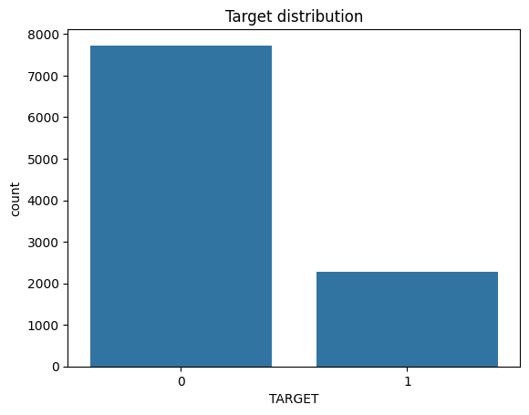

```python
sns.countplot(x="TARGET", data=train)
plt.title("Target distribution")
plt.show()
```

```python
num_cols = train.select_dtypes(include=["int64","float64"]).columns
num_cols = num_cols.drop("TARGET")
```

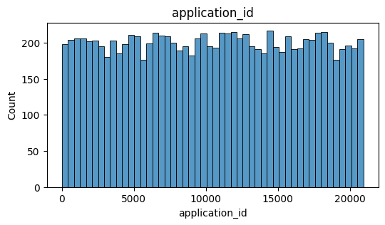

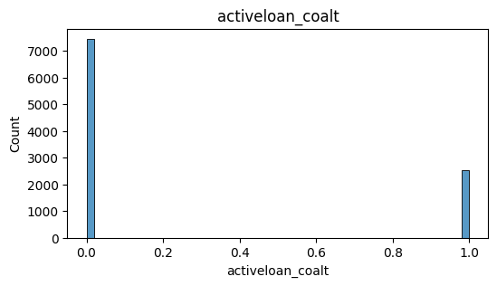

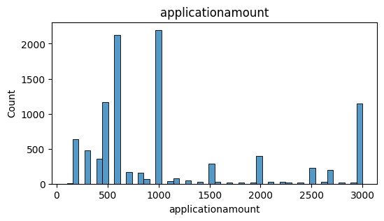

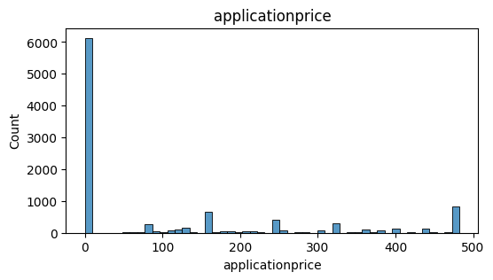

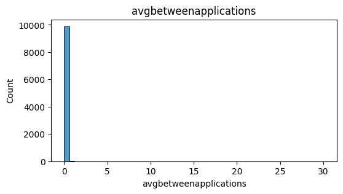

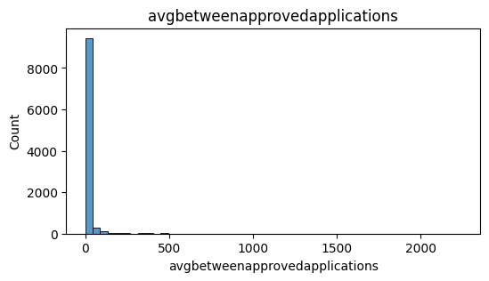

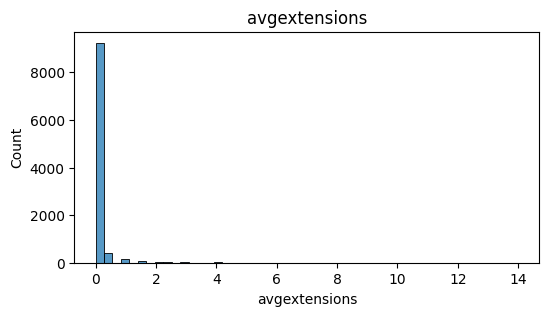

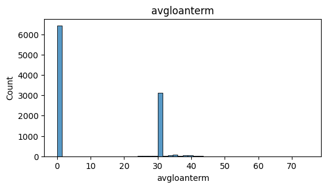

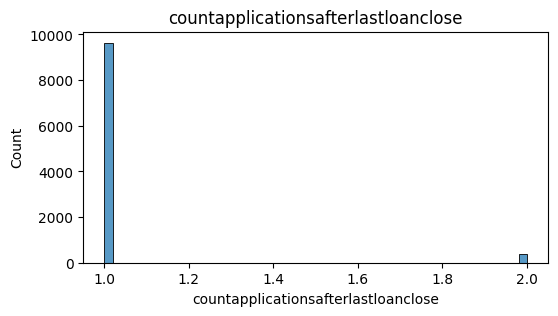

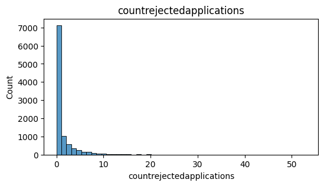

```python
for col in num_cols[:10]:

    plt.figure(figsize=(6,3))
    sns.histplot(train[col], bins=50)
    plt.title(col)
    plt.show()
```

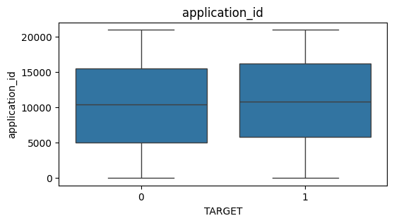

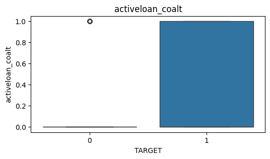

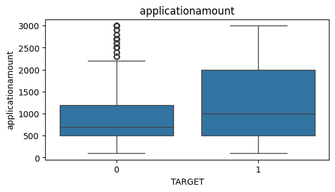

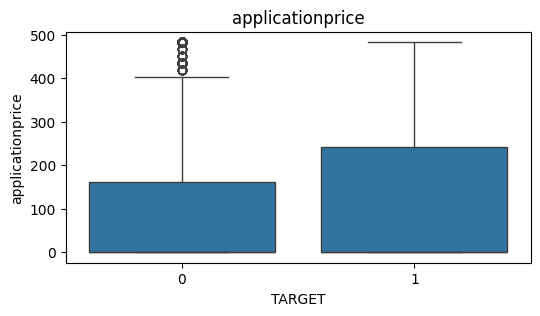

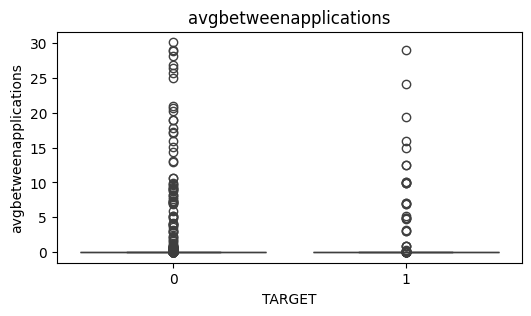

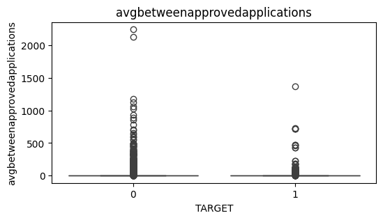

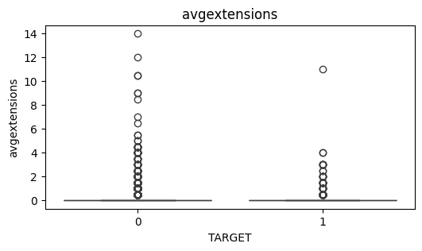

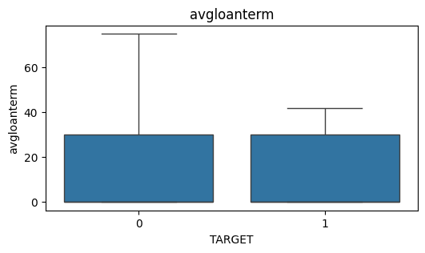

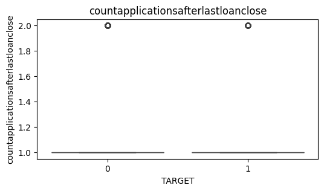

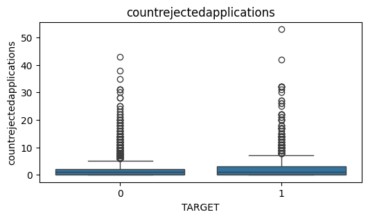

```python
for col in num_cols[:10]:

    plt.figure(figsize=(6,3))
    sns.boxplot(x="TARGET", y=col, data=train)
    plt.title(col)
    plt.show()
```

Several features exhibit strong asymmetry and a large number of outliers.

Some features, such as applicationamount and activeloan_coalt, demonstrate differences between classes and may be useful for the model.

Identifiers, such as application_id, do not carry predictive information and should be excluded.

Encoding categorical features

```python
cat_cols = train.select_dtypes(include=["object","category"]).columns
cat_cols
```

```
Index(['citysize', 'companiesinhouse', 'gender', 'householdsize', 'housesize',
       'legalform', 'value', 'housetype', 'identificationtype'],
      dtype='object')
```

```python
train = pd.get_dummies(train, columns=cat_cols, drop_first=True)
testdf = pd.get_dummies(testdf, columns=cat_cols, drop_first=True)
```

```python
from sklearn.metrics import roc_auc_score
import numpy as np
import pandas as pd

# using only numerical features
num_cols = train.select_dtypes(include=["int64","float64"]).columns
num_cols = num_cols.drop("TARGET")

auc_scores = []

for col in num_cols:

    # remove NaN for calculation
    tmp = train[[col, "TARGET"]].dropna()

    if tmp[col].nunique() > 1:
        auc = roc_auc_score(tmp["TARGET"], tmp[col])
        auc_scores.append((col, auc))

auc_df = pd.DataFrame(auc_scores, columns=["feature","auc"])

# features where auc is far from 0.5
auc_df["auc_abs"] = abs(auc_df["auc"] - 0.5)

top_features = auc_df.sort_values("auc_abs", ascending=False).head(10)

top_features
```

|  | feature | auc | auc_abs |
| --- | --- | --- | --- |
| 205 | num_prepaid_loans | 0.367910 | 0.132090 |
| 31 | num_positive_accounts | 0.369770 | 0.130230 |
| 220 | paidobligationscount | 0.370210 | 0.129790 |
| 32 | sum_positive_accounts | 0.372721 | 0.127279 |
| 223 | sumpaiddebt | 0.373684 | 0.126316 |
| 163 | swo_ind_same_pesel_different_lender_count_uniq... | 0.620129 | 0.120129 |
| 142 | swo_ind_same_pesel_applications_count_p0_7 | 0.619522 | 0.119522 |
| 143 | swo_ind_same_pesel_applications_count_p0_30 | 0.617821 | 0.117821 |
| 164 | swo_ind_same_pesel_different_lender_count_uniq... | 0.617411 | 0.117411 |
| 104 | swo_ind_loans_number_p0_plus | 0.383997 | 0.116003 |

Variables describing positive credit history (e.g. number of prepaid loans, total paid debt) also showed strong predictive ability but in the opposite direction, indicating lower default risk for clients with a stronger credit history.

Several variables exhibited strong right skewness and significant outliers. Logarithmic transformation (log1p) was applied to stabilize the variance and reduce the impact of extreme values.

The plots show strong asymmetry. It is better to apply a log transformation.

```python
skewed_cols = [
"applicationamount",
"avgbetweenapplications",
"avgbetweenapprovedapplications",
"avgextensions",
"avg_prepaid_days",
"avg_dpd",
"amounttotal",
"sumpaiddebt"
]

for col in skewed_cols:

    train[col+"_log"] = np.log1p(train[col])
    testdf[col+"_log"] = np.log1p(testdf[col])
```

# Correlation Analysis

```python
corr_cols = [
"applicationamount_log",
"avgbetweenapplications_log",
"avgextensions_log",
"avgloanterm",
"income_charge",
"onavgdpd",
"sum_positive_accounts",
"amounttotal_log",
"amounttotalopen",
"swo_ind_active_loans_amount",
"swo_ind_active_loans_open_amount",
"avg_prepaid_days_log",
"avg_dpd_log",
"sumpaiddebt_log",
"swo_ind_loans_amount_p0_7",
"swo_ind_loans_amount_p0_30",
"swo_ind_loans_amount_p0_360"
]

corr_dataset = train[corr_cols]
```

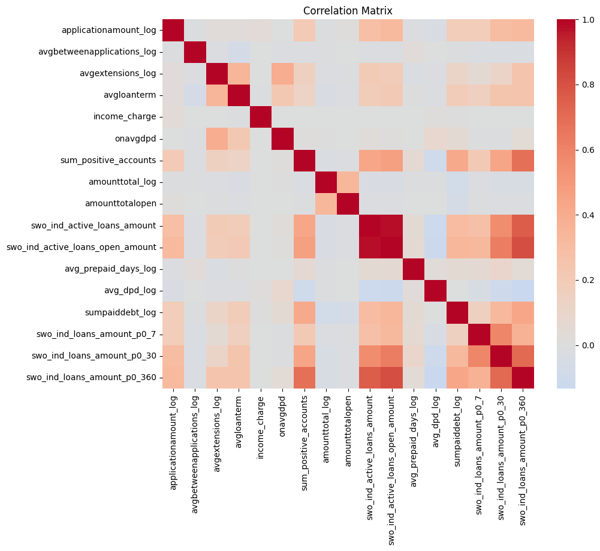

```python
import seaborn as sns
import matplotlib.pyplot as plt

corr_matrix = corr_dataset.corr()

plt.figure(figsize=(10,8))
sns.heatmap(corr_matrix, cmap="coolwarm", center=0)
plt.title("Correlation Matrix")
plt.show()
```

```python
corr_matrix = corr_dataset.corr().abs()

upper = corr_matrix.where(
    np.triu(np.ones(corr_matrix.shape), k=1).astype(bool)
)

high_corr = [col for col in upper.columns if any(upper[col] > 0.9)]

high_corr
```

```
['swo_ind_active_loans_open_amount']
```

Correlation analysis revealed several groups of highly correlated variables related to loan exposure and credit activity over different time windows. To avoid multicollinearity, redundant variables were removed while keeping representative features capturing both short-term and long-term credit behaviour.

Most remaining features show low correlation with each other, indicating that they provide complementary information for the prediction model.

Loan exposure These indicators reflect the customer's financial burden.

applicationamount_log amounttotal_log amounttotalopen income_charge avgloanterm Large loans and high debt burdens increase the risk of default.

Credit shopping avgbetweenapplications_log avgbetweenapprovedapplications_log avgextensions_log Frequent applications or loan extensions may signal financial difficulties.

Repayment behaviour avg_dpd_log onavgdpd avg_prepaid_days_log Delays and early repayments are directly related to the probability of default.

Credit history quality sum_positive_accounts num_positive_accounts num_prepaid_loans sumpaiddebt_log paidobligationscount Why they are important The more successful repayments, the lower the risk of default.

Current exposure swo_ind_active_loans_open_amount swo_ind_loans_amount_p0_7 swo_ind_loans_amount_p0_360 They show the customer's current debt burden and credit activity.

Information from credit bureaus providerscount creditorscount A large number of creditors may indicate increased risk.

Feature selection was performed using a combination of univariate AUC analysis and correlation analysis.

Variables demonstrating predictive power while avoiding strong multicollinearity were retained. The final feature set includes variables describing loan size, repayment behaviour, credit history, and recent credit activity.

```python
leakage_check = train.corr()["TARGET"].abs().sort_values(ascending=False)

leakage_check.head(15)
```

|  | TARGET |
| --- | --- |
| TARGET | 1.000000 |
| swo_ind_same_pesel_different_lender_count_unique_p0_30 | 0.177944 |
| sumpaiddebt_log | 0.177300 |
| swo_ind_same_pesel_different_lender_count_unique_p0_7 | 0.175588 |
| providerscount | 0.169914 |
| swo_ind_same_pesel_applications_count_p0_30 | 0.167713 |
| swo_ind_same_pesel_applications_count_p0_7 | 0.166203 |
| num_positive_accounts | 0.159601 |
| num_prepaid_loans | 0.155224 |
| swo_ind_same_pesel_different_lender_count_unique_p0_90 | 0.144636 |
| masterriskstatus_no_negative_history | 0.144286 |
| swo_ind_loans_number_p0_plus | 0.140489 |
| swo_ind_same_pesel_different_lender_count_unique_p0_3 | 0.140067 |
| paidobligationscount | 0.133940 |
| swo_ind_loans_number_p0_360 | 0.130258 |

**dtype:** float64

A leakage check was performed by examining correlations between the features and the target variable.

The highest correlations are relatively low (around 0.17–0.18), which is typical for credit risk datasets where default behaviour depends on multiple factors rather than a single variable.

No variables show suspiciously high correlation with the target, suggesting that the model does not rely on features containing direct information about the outcome.

```python
selected_features = [
"applicationamount_log",
"amounttotal_log",
"amounttotalopen",
"income_charge",
"avgloanterm",
"avgbetweenapplications_log",
"avgbetweenapprovedapplications_log",
"avgextensions_log",
"avg_dpd_log",
"onavgdpd",
"avg_prepaid_days_log",
"sum_positive_accounts",
"num_positive_accounts",
"num_prepaid_loans",
"sumpaiddebt_log",
"paidobligationscount",
"swo_ind_active_loans_open_amount",
"swo_ind_loans_amount_p0_7",
"swo_ind_loans_amount_p0_360",
"providerscount",
"creditorscount"
]

X = train[selected_features]
y = train["TARGET"]
```

```python
import lightgbm as lgb
from sklearn.model_selection import train_test_split
from sklearn.metrics import roc_auc_score
import pandas as pd

X = train[selected_features]
y = train["TARGET"]

X_train, X_val, y_train, y_val = train_test_split(
    X, y,
    test_size=0.2,
    stratify=y,
    random_state=42
)
```

```python
model = lgb.LGBMClassifier(
    n_estimators=300,
    learning_rate=0.05,
    max_depth=5,
    random_state=42
)

model.fit(X_train, y_train)
```

[output not shown]

[output cut: 249 more lines]

[output not shown]

```
LGBMClassifier(learning_rate=0.05, max_depth=5, n_estimators=300,
               random_state=42)
```

```python
importance = pd.DataFrame({
    "feature": selected_features,
    "importance": model.feature_importances_
})

importance = importance.sort_values("importance", ascending=False)

importance
```

|  | feature | importance |
| --- | --- | --- |
| 16 | swo_ind_active_loans_open_amount | 706 |
| 18 | swo_ind_loans_amount_p0_360 | 667 |
| 10 | avg_prepaid_days_log | 522 |
| 14 | sumpaiddebt_log | 477 |
| 8 | avg_dpd_log | 427 |
| 11 | sum_positive_accounts | 371 |
| 17 | swo_ind_loans_amount_p0_7 | 303 |
| 0 | applicationamount_log | 298 |
| 3 | income_charge | 288 |
| 15 | paidobligationscount | 244 |
| 13 | num_prepaid_loans | 219 |
| 6 | avgbetweenapprovedapplications_log | 206 |
| 12 | num_positive_accounts | 153 |
| 9 | onavgdpd | 149 |
| 4 | avgloanterm | 118 |
| 7 | avgextensions_log | 107 |
| 19 | providerscount | 97 |
| 20 | creditorscount | 43 |
| 1 | amounttotal_log | 40 |
| 5 | avgbetweenapplications_log | 38 |
| 2 | amounttotalopen | 32 |

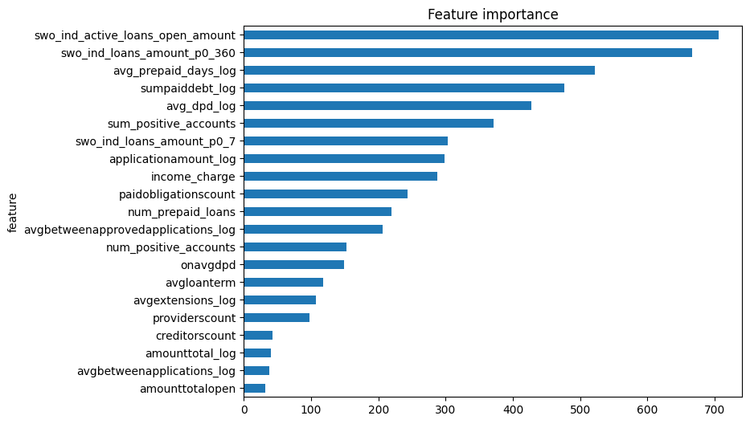

```python
importance.sort_values("importance").plot(
    x="feature",
    y="importance",
    kind="barh",
    figsize=(8,6),
    legend=False
)

plt.title("Feature importance")
plt.show()
```

Feature Importance Analysis

The feature importance analysis shows that variables related to current credit exposure, repayment behaviour and historical credit performance have the strongest predictive power in the model.

The most influential features include swo_ind_active_loans_open_amount, swo_ind_loans_amount_p0_360, avg_prepaid_days_log, sumpaiddebt_log, and avg_dpd_log. These variables reflect the client's current debt burden and payment discipline, which are key determinants of credit risk.

Variables describing positive credit history, such as the number of positive accounts and total repaid debt, also contribute significantly to the model. In addition, indicators related to recent credit activity, such as loan amounts in recent time windows, provide useful signals for identifying potentially risky borrowing behaviour.

Overall, the results confirm that the selected features capture the main drivers of default risk: current exposure, repayment behaviour, and credit history. This indicates that the feature engineering and selection steps were appropriate for building a probability of default model.

# Model Training

Final Predictive Model

To estimate the probability of default, two models were considered: Logistic Regression and LightGBM.

Logistic Regression was used as a baseline model because it is widely applied in credit scoring due to its interpretability and stability. The model allows straightforward interpretation of the relationship between predictors and default risk.

In addition, a LightGBM classifier was trained to capture potential non-linear relationships between features and the target variable. Gradient boosting models often achieve higher predictive performance while still maintaining reasonable interpretability through feature importance analysis.

Both models were evaluated using the ROC-AUC metric, which is commonly used for binary classification problems in credit risk modelling.

After comparing model performance on the validation dataset, the final model was selected based on predictive accuracy and stability.

The chosen model was then applied to the test dataset to estimate the probability of default for each observation.

```python
from sklearn.linear_model import LogisticRegression
from sklearn.metrics import roc_auc_score

log_model = LogisticRegression(max_iter=1000)

log_model.fit(X_train, y_train)

pred_log = log_model.predict_proba(X_val)[:,1]

roc_auc_score(y_val, pred_log)
```

```
np.float64(0.6513289946299655)
```

```python
import lightgbm as lgb

lgb_model = lgb.LGBMClassifier(
    n_estimators=300,
    learning_rate=0.05,
    max_depth=5,
    random_state=42
)

lgb_model.fit(X_train, y_train)

pred_lgb = lgb_model.predict_proba(X_val)[:,1]

roc_auc_score(y_val, pred_lgb)
```

[output not shown]

[output cut: 249 more lines]

[output not shown]

```
np.float64(0.8027568547956898)
```

```python
final_pred = lgb_model.predict_proba(testdf[selected_features])[:,1]

submission = pd.DataFrame({
    "PD": final_pred
})

submission.head()
```

|  | PD |
| --- | --- |
| 0 | 0.068229 |
| 1 | 0.195368 |
| 2 | 0.030506 |
| 3 | 0.234429 |
| 4 | 0.203024 |

# Model Evaluation

Model performance was evaluated using ROC-AUC, which is widely used in credit risk modelling for imbalanced classification problems.

Additionally, the Kolmogorov–Smirnov (KS) statistic was calculated to measure the model’s ability to distinguish between defaulted and non-defaulted clients.

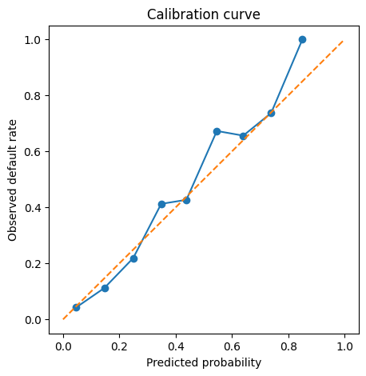

```python
from sklearn.calibration import calibration_curve
import matplotlib.pyplot as plt

prob_true, prob_pred = calibration_curve(y_val, pred_lgb, n_bins=10)

plt.figure(figsize=(5,5))
plt.plot(prob_pred, prob_true, marker="o")
plt.plot([0,1],[0,1], linestyle="--")
plt.xlabel("Predicted probability")
plt.ylabel("Observed default rate")
plt.title("Calibration curve")
plt.show()
```

```python
from sklearn.calibration import CalibratedClassifierCV

calibrated_model = CalibratedClassifierCV(lgb_model, method="sigmoid", cv=5)

calibrated_model.fit(X_train, y_train)

pred_cal = calibrated_model.predict_proba(X_val)[:,1]
```

[output not shown]

[output cut: 1471 more lines]

[output not shown]

```python
test_pd = calibrated_model.predict_proba(testdf[selected_features])[:,1]

submission = pd.DataFrame({
    "PD": test_pd
})

submission.head()
```

|  | PD |
| --- | --- |
| 0 | 0.067360 |
| 1 | 0.151770 |
| 2 | 0.065419 |
| 3 | 0.282669 |
| 4 | 0.254776 |

```python
from sklearn.metrics import roc_auc_score

roc_auc_score(y_val, pred_cal)
```

```
np.float64(0.8123781073295637)
```

```python
def ks_statistic(y_true, y_pred):

    df = pd.DataFrame({
        "y": y_true,
        "score": y_pred
    })

    df = df.sort_values("score")

    df["good"] = 1 - df["y"]
    df["bad"] = df["y"]

    df["cum_good"] = df["good"].cumsum() / df["good"].sum()
    df["cum_bad"] = df["bad"].cumsum() / df["bad"].sum()

    ks = np.max(np.abs(df["cum_bad"] - df["cum_good"]))

    return ks
```

```python
ks = ks_statistic(y_val, pred_lgb)

print("KS statistic:", ks)
```

```
KS statistic: 0.48251360290195233
```

```python
def plot_ks(y_true, y_pred):

    df = pd.DataFrame({
        "y": y_true,
        "score": y_pred
    }).sort_values("score")

    df["good"] = 1 - df["y"]
    df["bad"] = df["y"]

    df["cum_good"] = df["good"].cumsum() / df["good"].sum()
    df["cum_bad"] = df["bad"].cumsum() / df["bad"].sum()

    df["population"] = np.arange(1, len(df)+1) / len(df)

    ks = np.max(np.abs(df["cum_bad"] - df["cum_good"]))

    plt.figure(figsize=(6,4))
    plt.plot(df["population"], df["cum_good"], label="Good")
    plt.plot(df["population"], df["cum_bad"], label="Bad")

    plt.title(f"KS Curve (KS = {ks:.3f})")
    plt.xlabel("Population")
    plt.ylabel("Cumulative Distribution")

    plt.legend()
    plt.show()

    return ks
```

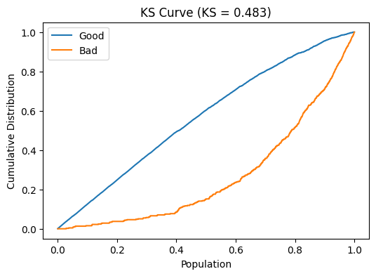

```
KS statistic: 0.48251360290195233
```

```python
ks = plot_ks(y_val, pred_lgb)

print("KS statistic:", ks)
```

KS Statistic

The Kolmogorov–Smirnov (KS) statistic was used to evaluate the model’s ability to separate defaulted and non-defaulted clients.

The KS value obtained for the validation dataset is 0.483, indicating strong discriminatory power. The model is able to clearly distinguish between higher-risk and lower-risk borrowers.

```python
from sklearn.model_selection import StratifiedKFold
from sklearn.metrics import roc_auc_score
import numpy as np

kf = StratifiedKFold(n_splits=5, shuffle=True, random_state=42)

auc_scores = []

for train_idx, val_idx in kf.split(X, y):

    X_tr, X_val = X.iloc[train_idx], X.iloc[val_idx]
    y_tr, y_val = y.iloc[train_idx], y.iloc[val_idx]

    model = lgb.LGBMClassifier(
        n_estimators=300,
        learning_rate=0.05,
        max_depth=5,
        random_state=42
    )

    model.fit(X_tr, y_tr)

    pred = model.predict_proba(X_val)[:,1]

    auc = roc_auc_score(y_val, pred)

    auc_scores.append(auc)

print("Mean AUC:", np.mean(auc_scores))
print("Std AUC:", np.std(auc_scores))
```

[output not shown]

[output cut: 1462 more lines]

[output not shown]

To evaluate the robustness of the model, 5-fold stratified cross-validation was performed.

The model achieved a mean ROC-AUC score of approximately 0.81 with a standard deviation of 0.008.

These results indicate that the model demonstrates strong predictive performance and stable behaviour across different folds of the data, suggesting good generalization ability.

# Final model & Prediction for test

```python
final_model = lgb.LGBMClassifier(
    n_estimators=300,
    learning_rate=0.05,
    max_depth=5,
    random_state=42
)

final_model.fit(X, y)
```

[output not shown]

[output cut: 245 more lines]

[output not shown]

```
LGBMClassifier(learning_rate=0.05, max_depth=5, n_estimators=300,
               random_state=42)
```

```python
testdf[selected_features]
```

|  | applicationamount_log | amounttotal_log | amounttotalopen | income_charge | avgloanterm | avgbetweenapplications_log | avgbetweenapprovedapplications_log | avgextensions_log | avg_dpd_log | onavgdpd | avg_prepaid_days_log | sum_positive_accounts | num_positive_accounts | num_prepaid_loans | sumpaiddebt_log | paidobligationscount | swo_ind_active_loans_open_amount | swo_ind_loans_amount_p0_7 | swo_ind_loans_amount_p0_360 | providerscount | creditorscount |
| --- | --- | --- | --- | --- | --- | --- | --- | --- | --- | --- | --- | --- | --- | --- | --- | --- | --- | --- | --- | --- | --- |
| 0 | 6.908755 | 0.0 | 0.0 | 0.00 | 30.0 | 0.0 | 0.00000 | 0.0 | 1.504077 | 0.0 | 1.757858 | 16190.11 | 5.0 | 5.0 | 9.749471 | 6.0 | 35386.50 | 0.00 | 68485.80 | 2.0 | 0.0 |
| 1 | 6.398595 | 0.0 | 0.0 | 0.00 | 0.0 | 0.0 | 0.00000 | 0.0 | 3.178054 | 0.0 | 2.427748 | 7371.00 | 4.0 | 3.0 | 8.905568 | 4.0 | 0.00 | 0.00 | 0.00 | 1.0 | 0.0 |
| 2 | 5.303305 | 0.0 | 0.0 | 0.00 | 0.0 | 0.0 | 0.00000 | 0.0 | 1.504077 | 0.0 | 2.658351 | 15229.12 | 12.0 | 11.0 | 9.643175 | 12.0 | 15846.52 | 900.00 | 33510.62 | 2.0 | 0.0 |
| 3 | 8.006701 | 0.0 | 0.0 | 0.14 | 0.0 | 0.0 | 0.00000 | 0.0 | 1.526056 | 0.0 | 2.639057 | 12884.57 | 10.0 | 3.0 | 9.462723 | 10.0 | 10287.82 | 0.00 | 28345.31 | 2.0 | 0.0 |
| 4 | 7.824446 | 0.0 | 0.0 | 0.08 | 0.0 | 0.0 | 0.00000 | 0.0 | 2.564949 | 0.0 | 2.525729 | 1525.00 | 2.0 | 0.0 | 7.893580 | 5.0 | 1170.47 | 0.00 | 5696.87 | 2.0 | 0.0 |
| ... | ... | ... | ... | ... | ... | ... | ... | ... | ... | ... | ... | ... | ... | ... | ... | ... | ... | ... | ... | ... | ... |
| 4641 | 8.006701 | 0.0 | 0.0 | 0.05 | 27.5 | 0.0 | 3.43431 | 0.0 | 1.504077 | 0.0 | 2.140066 | 5500.00 | 2.0 | 2.0 | 8.612685 | 2.0 | 48241.51 | 0.00 | 60364.31 | 2.0 | 0.0 |
| 4642 | 6.908755 | 0.0 | 0.0 | 0.06 | 0.0 | 0.0 | 0.00000 | 0.0 | 2.639057 | 0.0 | 2.525729 | 1936.00 | 1.0 | 0.0 | 7.569102 | 1.0 | 16926.25 | 0.00 | 27898.68 | 1.0 | 0.0 |
| 4643 | 6.216606 | 0.0 | 0.0 | 0.00 | 0.0 | 0.0 | 0.00000 | 0.0 | 0.693147 | 0.0 | 2.028148 | 10210.71 | 8.0 | 5.0 | 8.935349 | 7.0 | 11521.83 | 0.00 | 19449.41 | 1.0 | 0.0 |
| 4644 | 6.908755 | 0.0 | 0.0 | 0.00 | 0.0 | 0.0 | 0.00000 | 0.0 | 1.504077 | 0.0 | 0.693147 | 5223.69 | 3.0 | 1.0 | 8.150670 | 2.0 | 15075.46 | 10947.15 | 26691.81 | 1.0 | 0.0 |
| 4645 | 6.216606 | 0.0 | 0.0 | 0.00 | 30.0 | 0.0 | 0.00000 | 0.0 | 0.693147 | 0.0 | 2.525729 | 1271.00 | 1.0 | 0.0 | 7.149053 | 1.0 | 4935.92 | 0.00 | 7648.44 | 1.0 | 0.0 |

4646 rows × 21 columns

```python
set(selected_features) - set(testdf.columns)
```

```
set()
```

```python
X.columns
```

```
Index(['applicationamount_log', 'amounttotal_log', 'amounttotalopen',
       'income_charge', 'avgloanterm', 'avgbetweenapplications_log',
       'avgbetweenapprovedapplications_log', 'avgextensions_log',
       'avg_dpd_log', 'onavgdpd', 'avg_prepaid_days_log',
       'sum_positive_accounts', 'num_positive_accounts', 'num_prepaid_loans',
       'sumpaiddebt_log', 'paidobligationscount',
       'swo_ind_active_loans_open_amount', 'swo_ind_loans_amount_p0_7',
       'swo_ind_loans_amount_p0_360', 'providerscount', 'creditorscount'],
      dtype='object')
```

```python
testdf[selected_features].columns
```

```
Index(['applicationamount_log', 'amounttotal_log', 'amounttotalopen',
       'income_charge', 'avgloanterm', 'avgbetweenapplications_log',
       'avgbetweenapprovedapplications_log', 'avgextensions_log',
       'avg_dpd_log', 'onavgdpd', 'avg_prepaid_days_log',
       'sum_positive_accounts', 'num_positive_accounts', 'num_prepaid_loans',
       'sumpaiddebt_log', 'paidobligationscount',
       'swo_ind_active_loans_open_amount', 'swo_ind_loans_amount_p0_7',
       'swo_ind_loans_amount_p0_360', 'providerscount', 'creditorscount'],
      dtype='object')
```

```python
test_pd = final_model.predict_proba(testdf[selected_features])[:,1]
```

```python
submission = pd.DataFrame({
    "application_id": testdf["application_id"],
    "PD": test_pd
})
```

```python
submission.head()
```

|  | application_id | PD |
| --- | --- | --- |
| 0 | 223 | 0.037010 |
| 1 | 20671 | 0.262907 |
| 2 | 2218 | 0.032970 |
| 3 | 19196 | 0.279159 |
| 4 | 13088 | 0.257489 |

```python
submission.to_csv("pd_predictions.csv", index=False)
```

# Conclusion

Conclusion

A probability of default model was developed using a structured machine learning pipeline including exploratory data analysis, feature engineering, feature selection and model validation.

Two modelling approaches were considered: Logistic Regression as a baseline model and LightGBM as a more flexible model capable of capturing non-linear relationships in the data.

Model performance was evaluated using ROC-AUC, KS statistic and cross-validation. The LightGBM model achieved strong predictive performance with a ROC-AUC of approximately 0.81 and a KS statistic of around 0.48, indicating good discriminatory power.

The final model was trained on the full training dataset and applied to the test dataset to generate probability of default predictions for each observation.

These predictions can be used to support credit risk assessment and pricing decisions.